# FaceBook_dataset

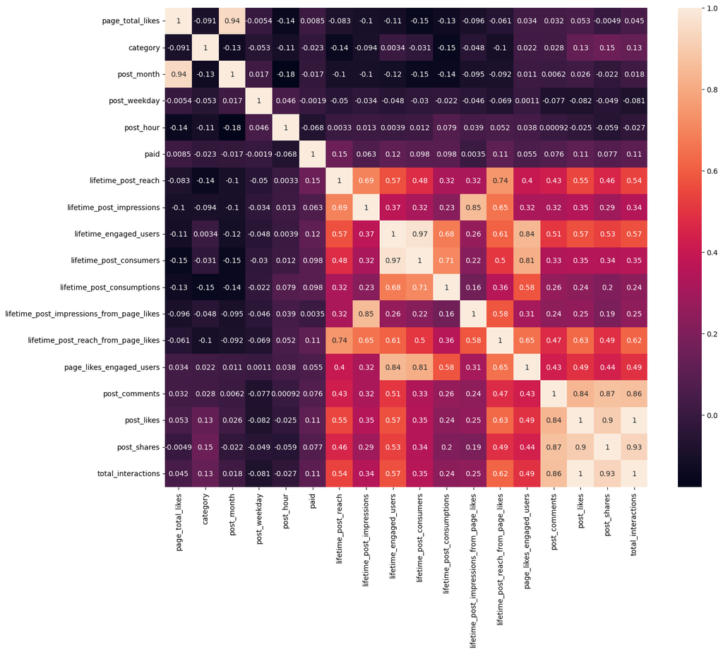

```python
plt.figure(figsize=(15,12))
sns.heatmap(data=df.corr(numeric_only=True),annot=True)
```

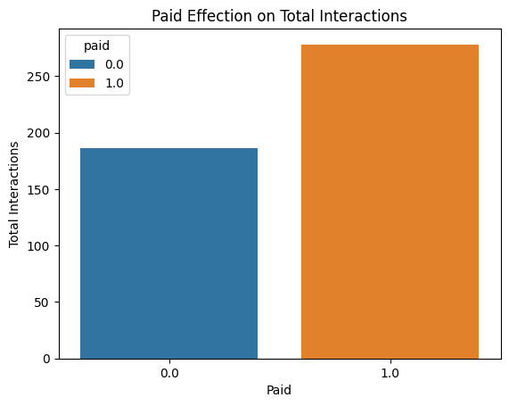

```python
plt.title('Paid Effection on Total Interactions')
sns.barplot(x='paid',y='total_interactions',hue='paid',data=df,ci=False)
plt.xlabel('Paid')
plt.ylabel('Total Interactions')
plt.show()
```

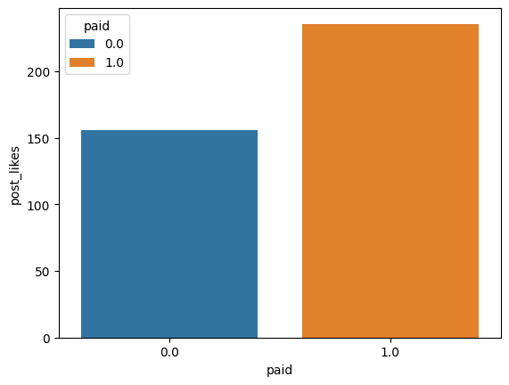

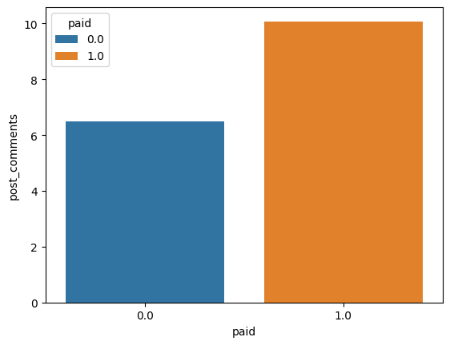

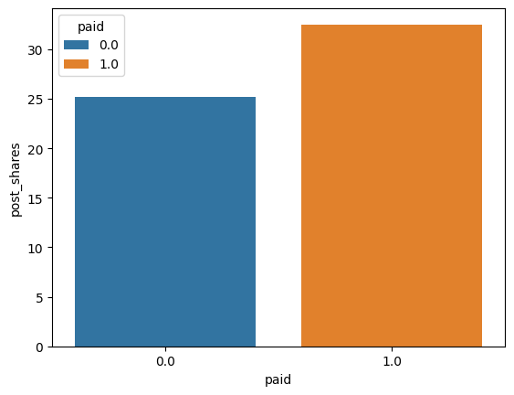

```python
interactions_list = ['post_likes','post_comments','post_shares']
for i in interactions_list:
    sns.barplot(x='paid',y=i,data=df,hue='paid',ci=False)
    plt.show()
```

##### Paid Vs Non-paid

- As expected Paid ones Must have A Higher `total_inteeractions` than Non-paid so we can tell that Paid is Making it job
- Paid increases `likes` `Comment` `share` !
- So by this Observation we Can tell that Paid has A good Effection on `Total Interaction`

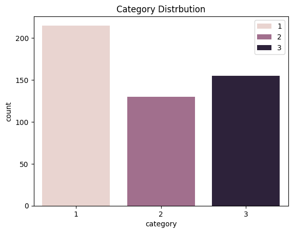

```python
# Count Size of Each Category Category 1 > 3 > 2
sns.countplot(x='category',hue='category',data=df)
plt.title('Category Distrbution')
plt.legend()
plt.show()
```

##### Category Can be Subdivided Into:

Category can be categorized into:

1. Actions Special Contest and Offers ( its business related the main differece it gives some kind of motivation like offers etc..)
2. Product direct Advertising (its basically Something related to Sales or Business )
3. inspiration non-explicit brand related content (Building A community rather than a businesses )

```python
df.groupby(['category','paid']).size()
```

```
category  paid
1         0.0     151
          1.0      64
2         0.0      98
          1.0      32
3         0.0     112
          1.0      43
dtype: int64
```

##### Catgegory/Paid

- as we can see most of the people are not paying for their promote
- lets try to figure it out if this promote is usefull in our total_interactions

```python
median_category_paid = df.groupby(['category','paid'])['total_interactions'].median().reset_index()
median_category_paid
```

|  | category | paid | total_interactions |
| --- | --- | --- | --- |
| 0 | 1 | 0.0 | 72.0 |
| 1 | 1 | 1.0 | 125.5 |
| 2 | 2 | 0.0 | 145.0 |
| 3 | 2 | 1.0 | 187.5 |
| 4 | 3 | 0.0 | 145.0 |
| 5 | 3 | 1.0 | 180.0 |

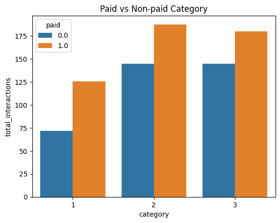

```python
sns.barplot(x= 'category',y = 'total_interactions',hue='paid',data=median_category_paid)
plt.title('Paid vs Non-paid Category')
plt.show()
```

##### Conclusion Of Category/Paid

- it seems that paid ones making their jobs, paid ones has much more interaction than unpaid ones
- it's so Obvious That we are now sure about Paid

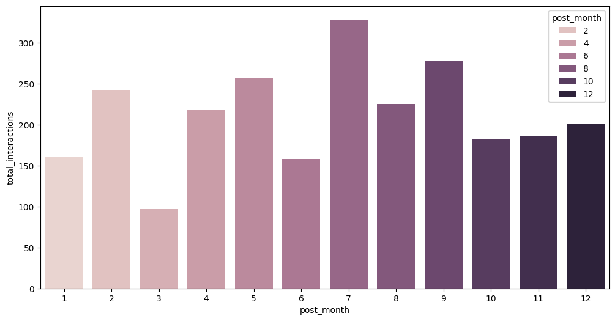

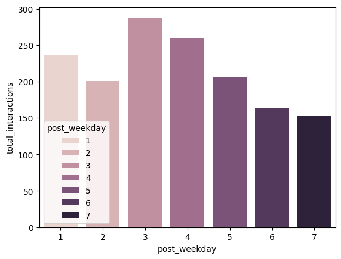

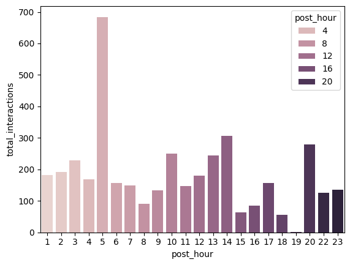

```python
change_post_time = ['post_month','post_weekday','post_hour']
plt.figure(figsize=(12,6))
for i in range(3):
    sns.barplot(x = change_post_time[i],y='total_interactions',data=df,hue=change_post_time[i],ci=False)
    plt.show()
```

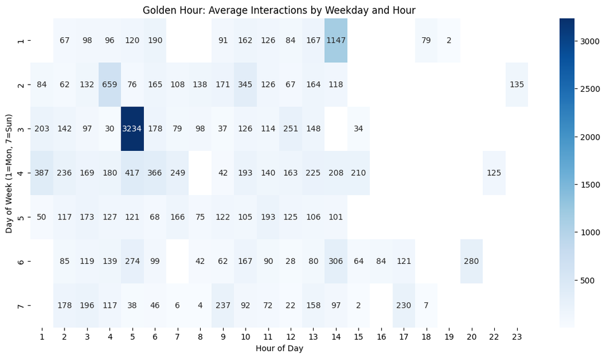

```python
heatmap_data = df.groupby(['post_weekday', 'post_hour'])['total_interactions'].median().unstack()
plt.figure(figsize=(14, 7))
sns.heatmap(heatmap_data, annot=True, cmap='Blues', fmt='.0f')
plt.title('Golden Hour: Average Interactions by Weekday and Hour')
plt.xlabel('Hour of Day')
plt.ylabel('Day of Week (1=Mon, 7=Sun)')
plt.show()
```

#### HeatMap Observation

- We Have Visualize Each Weekday and Hour so We can see when Does User Post So he Can go Viral Or have A High Interaction
- This Can be Seen In the `histogram` That we have Visualize Before But here it's More Specific Since we Are Ploting Which Week and Which Hour speifically

##### Date Observation

```python
df.head()
```

|  | page_total_likes | post_type | category | post_month | post_weekday | post_hour | paid | lifetime_post_reach | lifetime_post_impressions | lifetime_engaged_users | lifetime_post_consumers | lifetime_post_consumptions | lifetime_post_impressions_from_page_likes | lifetime_post_reach_from_page_likes | page_likes_engaged_users | post_comments | post_likes | post_shares | total_interactions | liked_group |
| --- | --- | --- | --- | --- | --- | --- | --- | --- | --- | --- | --- | --- | --- | --- | --- | --- | --- | --- | --- | --- |
| 0 | 139441 | Photo | 2 | 12 | 4 | 3 | 0.0 | 2752 | 5091 | 178 | 109 | 159 | 3078 | 1640 | 119 | 4 | 79.0 | 17.0 | 100 | High |
| 1 | 139441 | Status | 2 | 12 | 3 | 10 | 0.0 | 10460 | 19057 | 1457 | 1361 | 1674 | 11710 | 6112 | 1108 | 5 | 130.0 | 29.0 | 164 | High |
| 2 | 139441 | Photo | 3 | 12 | 3 | 3 | 0.0 | 2413 | 4373 | 177 | 113 | 154 | 2812 | 1503 | 132 | 0 | 66.0 | 14.0 | 80 | High |
| 3 | 139441 | Photo | 2 | 12 | 2 | 10 | 1.0 | 50128 | 87991 | 2211 | 790 | 1119 | 61027 | 32048 | 1386 | 58 | 1572.0 | 147.0 | 1777 | High |
| 4 | 139441 | Photo | 2 | 12 | 2 | 3 | 0.0 | 7244 | 13594 | 671 | 410 | 580 | 6228 | 3200 | 396 | 19 | 325.0 | 49.0 | 393 | High |

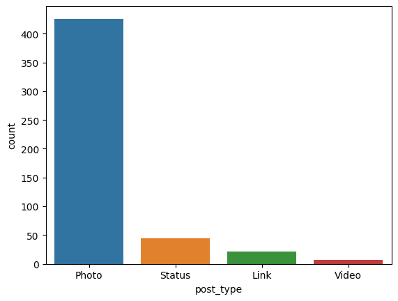

```python
# if we want to calculate something related to type we have to take mean or median since there's imbalance classes
sns.countplot(x='post_type',data=df,hue='post_type')
```

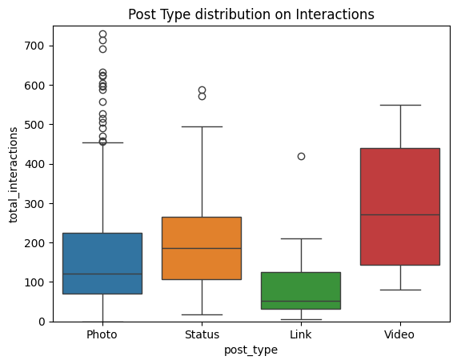

```python
# as we said before we can't evaluate Types by a normal calculation we have to use median and its available on boxplot
plt.title('Post Type distribution on Interactions')
sns.boxplot(x='post_type',y='total_interactions',data=df,hue='post_type')
plt.ylim(0,750)
plt.show()
```

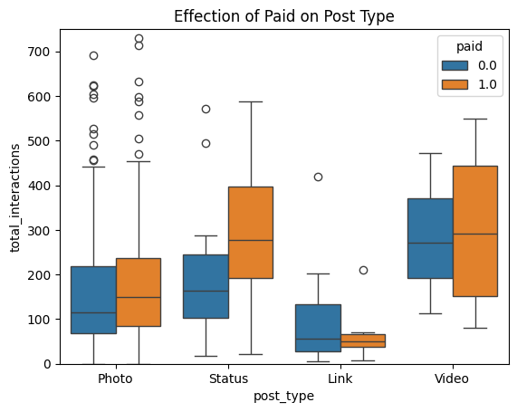

```python
plt.title('Effection of Paid on Post Type')
sns.boxplot(x='post_type',y='total_interactions',data=df,hue='paid')
plt.ylim(0,750)
plt.show()
```

##### Post Type / Paid

- We can notice How paid increases Post Type `Total Interaction`
- Esspicially in `Status` Where differences is very Noticed
- Links has a lower Observation and esspicially for Paid ones

```python
df['lifetime_post_reach'].describe()
```

```
count       500.00000
mean      13903.36000
std       22740.78789
min         238.00000
25%        3315.00000
50%        5281.00000
75%       13168.00000
max      180480.00000
Name: lifetime_post_reach, dtype: float64
```

```python
df['lifetime_post_impressions'].describe()
```

```
count    5.000000e+02
mean     2.958595e+04
std      7.680325e+04
min      5.700000e+02
25%      5.694750e+03
50%      9.051000e+03
75%      2.208550e+04
max      1.110282e+06
Name: lifetime_post_impressions, dtype: float64
```

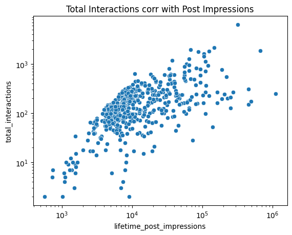

```python
plt.title('Total Interactions corr with Post Impressions')
sns.scatterplot(x='lifetime_post_impressions',y='total_interactions',data=df)
plt.yscale('log')
plt.xscale('log')
plt.show()
```

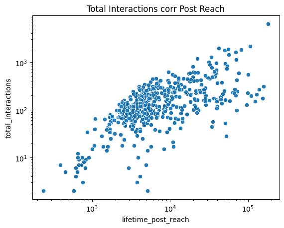

```python
plt.title('Total Interactions corr Post Reach')
sns.scatterplot(x='lifetime_post_reach',y='total_interactions',data=df)
plt.yscale('log')
plt.xscale('log')
```

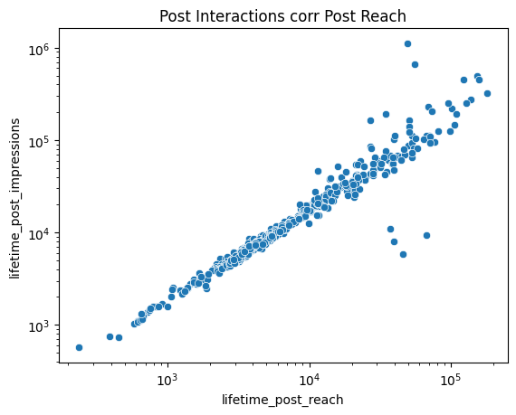

```python
plt.title('Post Interactions corr Post Reach')
sns.scatterplot(x='lifetime_post_reach',y='lifetime_post_impressions',data=df)
plt.yscale('log')
plt.xscale('log')
```

##### Post Impression/ Post Reach

- Post Reach and Post impression should have some Feature Engineerit has a high correleation it could lead us to `multicollinearity`
- we can either put the Ratio of them or Drop one of them

```python
df.loc[df['lifetime_post_impressions'] < df['lifetime_post_reach']] # there has to be something here!
```

|  | page_total_likes | post_type | category | post_month | post_weekday | post_hour | paid | lifetime_post_reach | lifetime_post_impressions | lifetime_engaged_users | lifetime_post_consumers | lifetime_post_consumptions | lifetime_post_impressions_from_page_likes | lifetime_post_reach_from_page_likes | page_likes_engaged_users | post_comments | post_likes | post_shares | total_interactions | liked_group |
| --- | --- | --- | --- | --- | --- | --- | --- | --- | --- | --- | --- | --- | --- | --- | --- | --- | --- | --- | --- | --- |
| 476 | 86909 | Photo | 1 | 1 | 6 | 10 | 1.0 | 37088 | 10966 | 2728 | 2288 | 3183 | 66311 | 34352 | 2021 | 7 | 579.0 | 47.0 | 633 | Low |
| 477 | 86909 | Link | 1 | 1 | 6 | 4 | 0.0 | 39600 | 7927 | 572 | 496 | 581 | 12522 | 8176 | 167 | 1 | 101.0 | 5.0 | 107 | Low |
| 482 | 86491 | Photo | 3 | 1 | 3 | 10 | 0.0 | 66784 | 9456 | 2969 | 2833 | 3645 | 17809 | 11328 | 801 | 3 | 187.0 | 36.0 | 226 | Low |
| 492 | 85979 | Link | 1 | 1 | 5 | 11 | 0.0 | 45920 | 5808 | 753 | 655 | 763 | 15766 | 10720 | 220 | 0 | 128.0 | 9.0 | 137 | Low |

```python
df.loc[:,['lifetime_engaged_users','lifetime_post_consumptions']]
```

|  | lifetime_engaged_users | lifetime_post_consumptions |
| --- | --- | --- |
| 0 | 178 | 159 |
| 1 | 1457 | 1674 |
| 2 | 177 | 154 |
| 3 | 2211 | 1119 |
| 4 | 671 | 580 |
| ... | ... | ... |
| 495 | 733 | 985 |
| 496 | 537 | 687 |
| 497 | 625 | 795 |
| 498 | 626 | 832 |
| 499 | 564 | 743 |

500 rows × 2 columns

```python
df.loc[df['lifetime_post_reach'] > df['lifetime_post_impressions']]
```

|  | page_total_likes | post_type | category | post_month | post_weekday | post_hour | paid | lifetime_post_reach | lifetime_post_impressions | lifetime_engaged_users | lifetime_post_consumers | lifetime_post_consumptions | lifetime_post_impressions_from_page_likes | lifetime_post_reach_from_page_likes | page_likes_engaged_users | post_comments | post_likes | post_shares | total_interactions | liked_group |
| --- | --- | --- | --- | --- | --- | --- | --- | --- | --- | --- | --- | --- | --- | --- | --- | --- | --- | --- | --- | --- |
| 476 | 86909 | Photo | 1 | 1 | 6 | 10 | 1.0 | 37088 | 10966 | 2728 | 2288 | 3183 | 66311 | 34352 | 2021 | 7 | 579.0 | 47.0 | 633 | Low |
| 477 | 86909 | Link | 1 | 1 | 6 | 4 | 0.0 | 39600 | 7927 | 572 | 496 | 581 | 12522 | 8176 | 167 | 1 | 101.0 | 5.0 | 107 | Low |
| 482 | 86491 | Photo | 3 | 1 | 3 | 10 | 0.0 | 66784 | 9456 | 2969 | 2833 | 3645 | 17809 | 11328 | 801 | 3 | 187.0 | 36.0 | 226 | Low |
| 492 | 85979 | Link | 1 | 1 | 5 | 11 | 0.0 | 45920 | 5808 | 753 | 655 | 763 | 15766 | 10720 | 220 | 0 | 128.0 | 9.0 | 137 | Low |

```python
df.loc[df['lifetime_engaged_users'] >= df['lifetime_post_consumers']]
```

|  | page_total_likes | post_type | category | post_month | post_weekday | post_hour | paid | lifetime_post_reach | lifetime_post_impressions | lifetime_engaged_users | lifetime_post_consumers | lifetime_post_consumptions | lifetime_post_impressions_from_page_likes | lifetime_post_reach_from_page_likes | page_likes_engaged_users | post_comments | post_likes | post_shares | total_interactions | liked_group |
| --- | --- | --- | --- | --- | --- | --- | --- | --- | --- | --- | --- | --- | --- | --- | --- | --- | --- | --- | --- | --- |
| 0 | 139441 | Photo | 2 | 12 | 4 | 3 | 0.0 | 2752 | 5091 | 178 | 109 | 159 | 3078 | 1640 | 119 | 4 | 79.0 | 17.0 | 100 | High |
| 1 | 139441 | Status | 2 | 12 | 3 | 10 | 0.0 | 10460 | 19057 | 1457 | 1361 | 1674 | 11710 | 6112 | 1108 | 5 | 130.0 | 29.0 | 164 | High |
| 2 | 139441 | Photo | 3 | 12 | 3 | 3 | 0.0 | 2413 | 4373 | 177 | 113 | 154 | 2812 | 1503 | 132 | 0 | 66.0 | 14.0 | 80 | High |
| 3 | 139441 | Photo | 2 | 12 | 2 | 10 | 1.0 | 50128 | 87991 | 2211 | 790 | 1119 | 61027 | 32048 | 1386 | 58 | 1572.0 | 147.0 | 1777 | High |
| 4 | 139441 | Photo | 2 | 12 | 2 | 3 | 0.0 | 7244 | 13594 | 671 | 410 | 580 | 6228 | 3200 | 396 | 19 | 325.0 | 49.0 | 393 | High |
| ... | ... | ... | ... | ... | ... | ... | ... | ... | ... | ... | ... | ... | ... | ... | ... | ... | ... | ... | ... | ... |
| 495 | 85093 | Photo | 3 | 1 | 7 | 2 | 0.0 | 4684 | 7536 | 733 | 708 | 985 | 4750 | 2876 | 392 | 5 | 53.0 | 26.0 | 84 | Low |
| 496 | 81370 | Photo | 2 | 1 | 5 | 8 | 0.0 | 3480 | 6229 | 537 | 508 | 687 | 3961 | 2104 | 301 | 0 | 53.0 | 22.0 | 75 | Low |
| 497 | 81370 | Photo | 1 | 1 | 5 | 2 | 0.0 | 3778 | 7216 | 625 | 572 | 795 | 4742 | 2388 | 363 | 4 | 93.0 | 18.0 | 115 | Low |
| 498 | 81370 | Photo | 3 | 1 | 4 | 11 | 0.0 | 4156 | 7564 | 626 | 574 | 832 | 4534 | 2452 | 370 | 7 | 91.0 | 38.0 | 136 | Low |
| 499 | 81370 | Photo | 2 | 1 | 4 | 4 | 0.0 | 4188 | 7292 | 564 | 524 | 743 | 3861 | 2200 | 316 | 0 | 91.0 | 28.0 | 119 | Low |

500 rows × 20 columns

```python
df.loc[df['lifetime_post_impressions'] < df['lifetime_post_impressions_from_page_likes']]
```

|  | page_total_likes | post_type | category | post_month | post_weekday | post_hour | paid | lifetime_post_reach | lifetime_post_impressions | lifetime_engaged_users | lifetime_post_consumers | lifetime_post_consumptions | lifetime_post_impressions_from_page_likes | lifetime_post_reach_from_page_likes | page_likes_engaged_users | post_comments | post_likes | post_shares | total_interactions | liked_group |
| --- | --- | --- | --- | --- | --- | --- | --- | --- | --- | --- | --- | --- | --- | --- | --- | --- | --- | --- | --- | --- |
| 476 | 86909 | Photo | 1 | 1 | 6 | 10 | 1.0 | 37088 | 10966 | 2728 | 2288 | 3183 | 66311 | 34352 | 2021 | 7 | 579.0 | 47.0 | 633 | Low |
| 477 | 86909 | Link | 1 | 1 | 6 | 4 | 0.0 | 39600 | 7927 | 572 | 496 | 581 | 12522 | 8176 | 167 | 1 | 101.0 | 5.0 | 107 | Low |
| 482 | 86491 | Photo | 3 | 1 | 3 | 10 | 0.0 | 66784 | 9456 | 2969 | 2833 | 3645 | 17809 | 11328 | 801 | 3 | 187.0 | 36.0 | 226 | Low |
| 492 | 85979 | Link | 1 | 1 | 5 | 11 | 0.0 | 45920 | 5808 | 753 | 655 | 763 | 15766 | 10720 | 220 | 0 | 128.0 | 9.0 | 137 | Low |

```python
df.drop(index = df.loc[df['lifetime_post_impressions'] < df['lifetime_post_impressions_from_page_likes']].index,inplace=True)
# we have Droped Them perfectly!
```

#### Analysis Result

- we have some Violations
1. `lifetime_post_reach` cant be > `lifetime_post_impressions`
2. `lifetime_post_impressions` cant be < `lifetime_post_impressions_from_page_likes`

1- We Have 4 Rows that violate 2 Rules and they are the same `Row: 476, 477, 482, 492`

- it Could be a Delay when they Gather Data, Or incorrect Insertion But at the end it's incorrect

```python
pct = df.groupby(['post_type','paid']).size().groupby(level=0).apply(lambda x : x/x.sum() * 100).unstack()
```

```python
pct
```

| post_type | paid post_type | 0.0 | 1.0 |
| --- | --- | --- | --- |
| Link | Link | 70.000000 | 30.000000 |
| Photo | Photo | 72.169811 | 27.830189 |
| Status | Status | 77.777778 | 22.222222 |
| Video | Video | 42.857143 | 57.142857 |

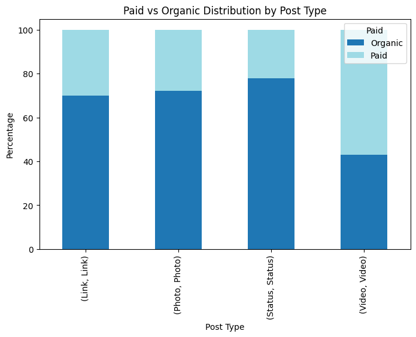

```python
pct.plot(
    kind='bar',
    stacked=True,
    figsize=(8,5),
    colormap='tab20'
)

plt.ylabel('Percentage')
plt.xlabel('Post Type')
plt.title('Paid vs Organic Distribution by Post Type')
plt.legend(title='Paid', labels=['Organic', 'Paid'])
plt.show()

# just to
```

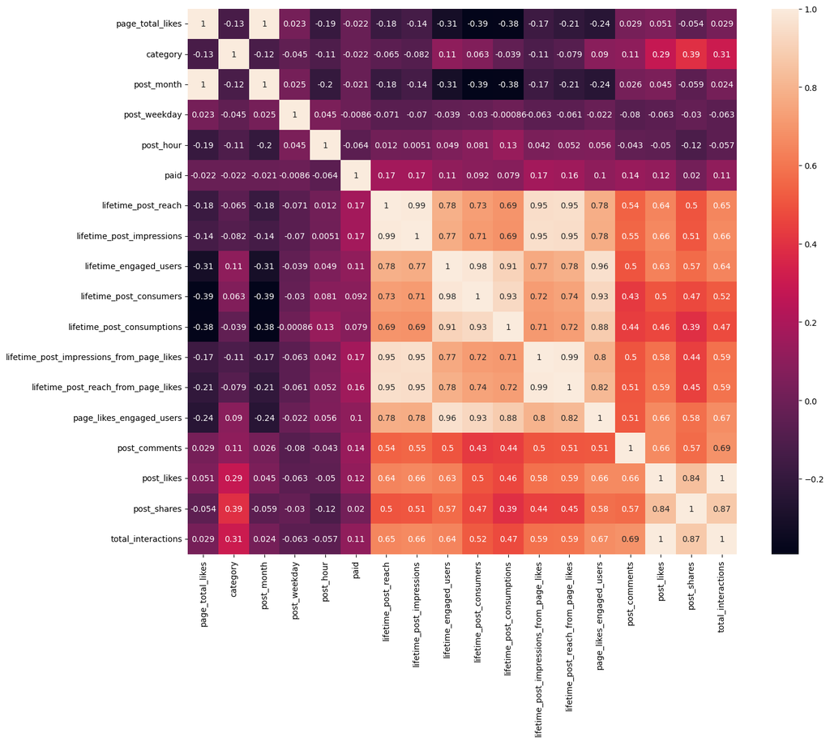

```python
plt.figure(figsize=(15,12))
sns.heatmap(df.corr(numeric_only=True,method='spearman'),annot=True)
```

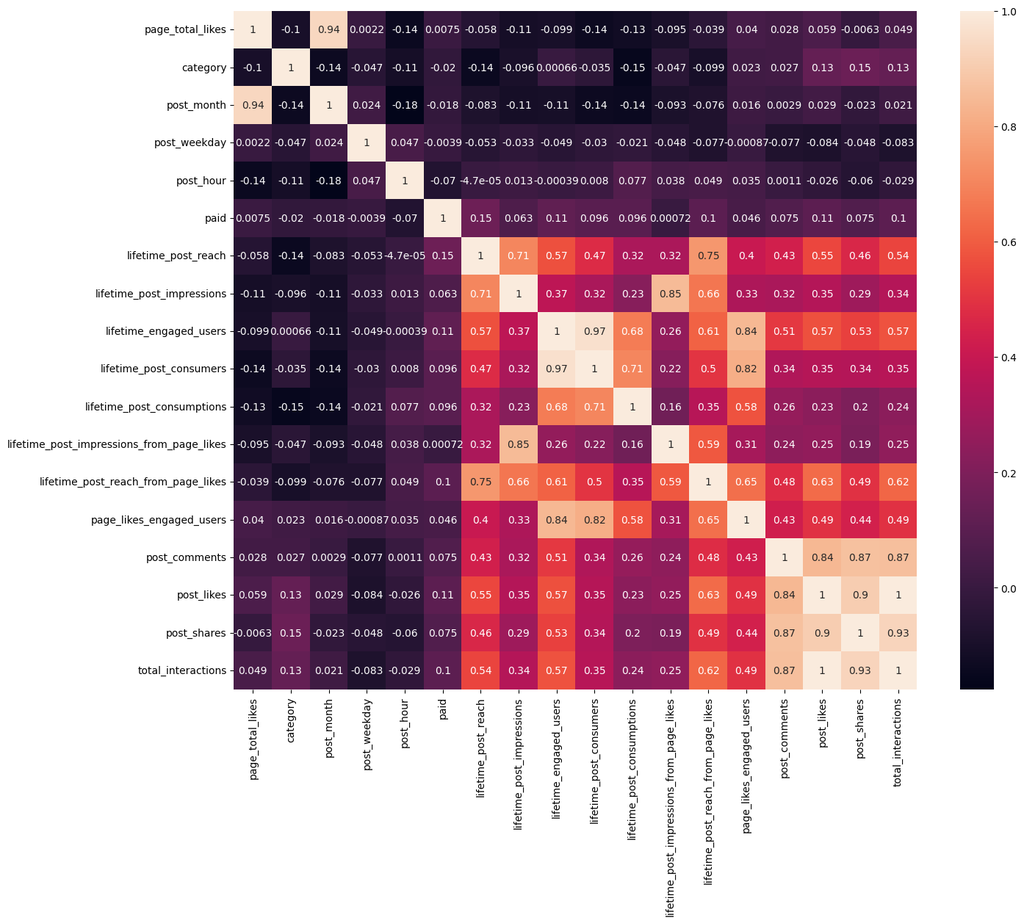

```python
plt.figure(figsize=(15,12))
sns.heatmap(df.corr(numeric_only=True),annot=True)
```

#### Concolusion of HeatMap

1. We have to remove `multicollinearity` correlations and there is many in our Case
2. We have Used Both Spearman for (Non-Linearity) and Pearson for (Linear Correlation)

##### Pearson & SpearMan

```python
df['post_ratio_imp_reach'] = df['lifetime_post_impressions'] / df['lifetime_post_reach']
df['post_ratio_imp_rach_likes'] = df['lifetime_post_impressions_from_page_likes'] / df['lifetime_post_reach_from_page_likes']
df['post_ratio_engaged_consumers'] = df['lifetime_post_consumers'] / df['lifetime_engaged_users']
df['post_ratio_engaged_consumption'] = df['lifetime_post_consumptions'] / df['page_likes_engaged_users']
```

#### Explaining New Columns

- `post_ratio_imp_reach` => How many Times did your post showed up for the Users
- `post_ratio_imp_reach_likes` => How many Times Did your followers Saw The post
- `post_ratio_engaged_consumers` => From the People Who Engaged to your post how many of them Consumed The post
- `post_ratio_engaged_consumption` => Same As previous one but here it's Calculating Avg of Each user Each ENgaged USer how many times did he Consume the post

```python
df.drop(columns=['lifetime_post_impressions_from_page_likes','lifetime_post_reach_from_page_likes','lifetime_engaged_users','lifetime_post_consumers','lifetime_post_reach','lifetime_post_impressions','lifetime_post_consumptions','page_likes_engaged_users','post_comments','post_likes','post_shares'],inplace=True)
```

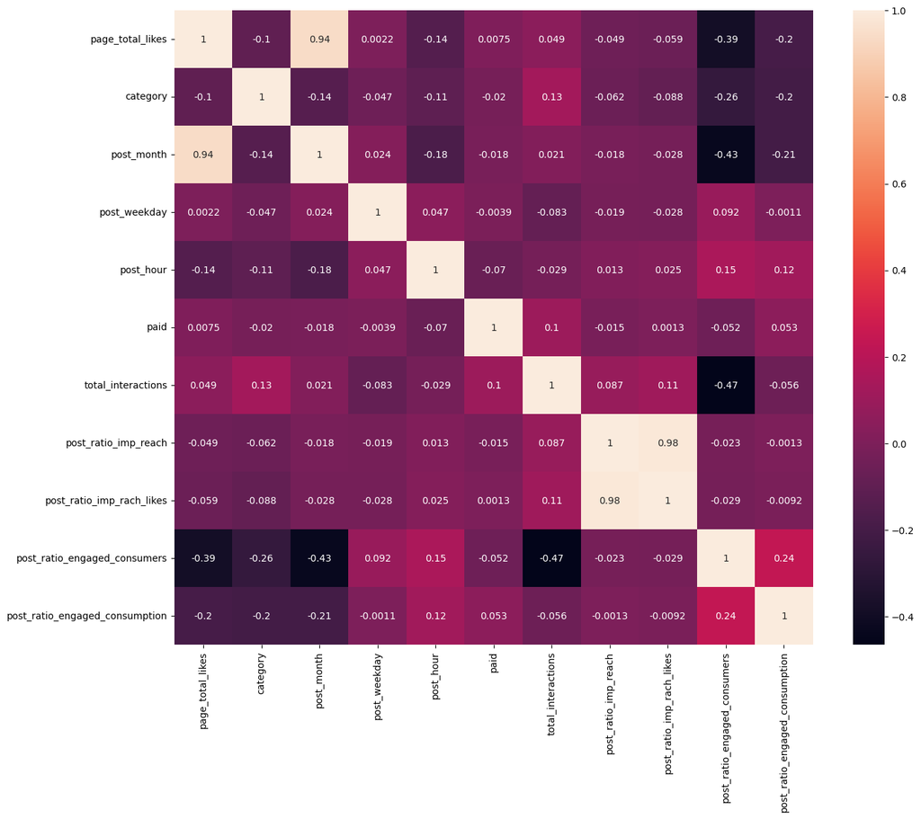

```python
plt.figure(figsize=(15,12))
sns.heatmap(df.corr(numeric_only=True),annot=True)
```

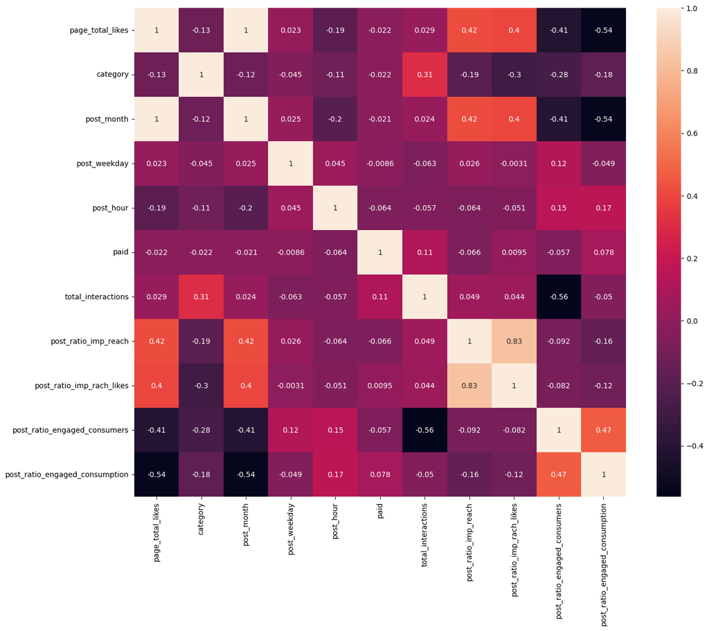

```python
plt.figure(figsize=(15,12))
sns.heatmap(df.corr(numeric_only=True,method='spearman'),annot=True)
```

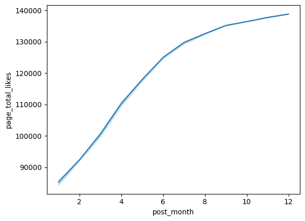

```python
sns.lineplot(x='post_month',y='page_total_likes',data=df)
# we haveb to drop page_total_likes since it has a perfect corr with post_month!!!
```

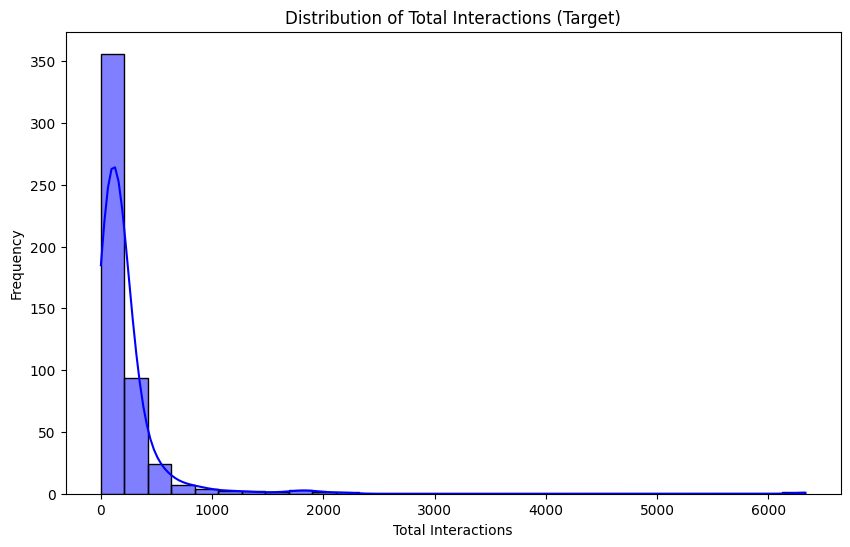

```python
plt.figure(figsize=(10, 6))
sns.histplot(df['total_interactions'], kde=True, color='blue', bins=30)
plt.title('Distribution of Total Interactions (Target)')
plt.xlabel('Total Interactions')
plt.ylabel('Frequency')
plt.show()

# Highely skwed Target which indicate we have some Outliers!!! and that will destroy our model prediction
```

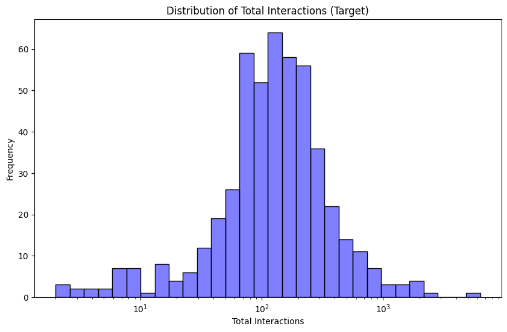

```python
plt.figure(figsize=(10, 6))
sns.histplot(df['total_interactions'], kde=True, color='blue', bins=30,log_scale=True)
plt.title('Distribution of Total Interactions (Target)')
plt.xlabel('Total Interactions')
plt.ylabel('Frequency')
plt.show()

# Now it's Normal Distribution which will make our prediction way better than before
```

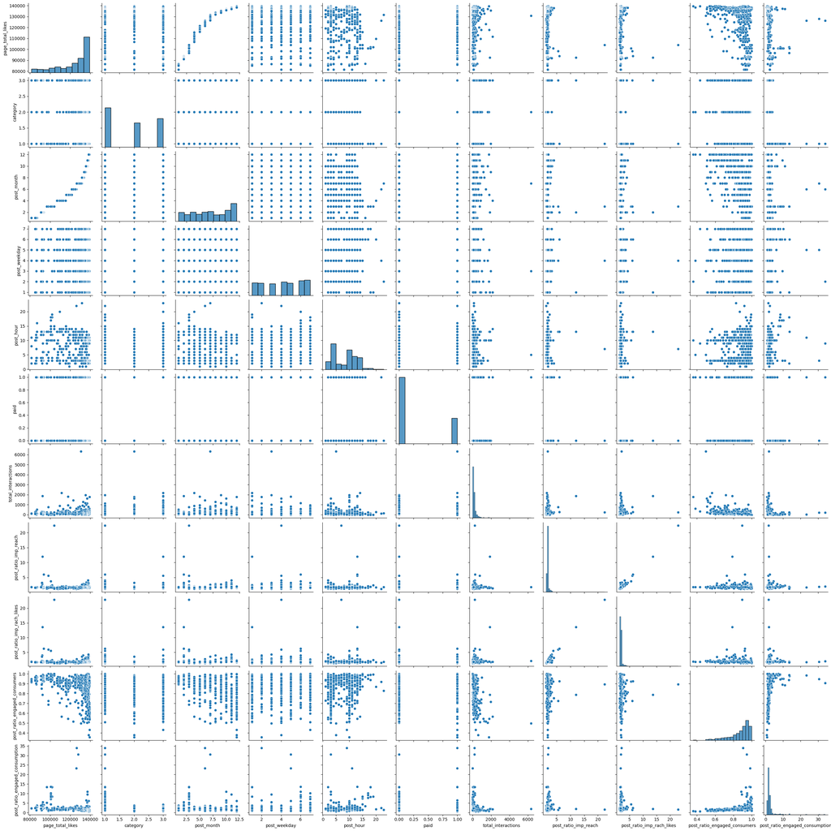

```python
sns.pairplot(data=df)
```

```python
df.describe()
```

|  | page_total_likes | category | post_month | post_weekday | post_hour | paid | total_interactions | post_ratio_imp_reach | post_ratio_imp_rach_likes | post_ratio_engaged_consumers | post_ratio_engaged_consumption |
| --- | --- | --- | --- | --- | --- | --- | --- | --- | --- | --- | --- |
| count | 496.000000 | 496.000000 | 496.000000 | 496.000000 | 496.000000 | 496.000000 | 496.000000 | 496.000000 | 496.000000 | 496.000000 | 496.000000 |
| mean | 123489.516129 | 1.883065 | 7.086694 | 4.143145 | 7.832661 | 0.278226 | 211.606855 | 1.885393 | 1.972814 | 0.864408 | 2.345722 |
| std | 16000.557823 | 0.851876 | 3.276261 | 2.034469 | 4.378347 | 0.448578 | 381.252265 | 1.103434 | 1.175253 | 0.121996 | 2.669812 |
| min | 81370.000000 | 1.000000 | 1.000000 | 1.000000 | 1.000000 | 0.000000 | 0.000000 | 1.172763 | 1.365748 | 0.357304 | 0.609649 |
| 25% | 113028.000000 | 1.000000 | 4.000000 | 2.000000 | 3.000000 | 0.000000 | 71.000000 | 1.665130 | 1.724681 | 0.814072 | 1.484825 |
| 50% | 129600.000000 | 2.000000 | 7.000000 | 4.000000 | 9.000000 | 0.000000 | 122.500000 | 1.761861 | 1.816318 | 0.905741 | 1.799556 |
| 75% | 136393.000000 | 3.000000 | 10.000000 | 6.000000 | 11.000000 | 1.000000 | 228.500000 | 1.875817 | 1.946658 | 0.953346 | 2.261318 |
| max | 139441.000000 | 3.000000 | 12.000000 | 7.000000 | 23.000000 | 1.000000 | 6334.000000 | 22.370285 | 22.904255 | 1.000000 | 33.926244 |